# White Wine Quality Exploration by Ying Xiong

The dataset we are looking at is presented by Cortez et al. (see reference below), which contains the large collection (about 5000) of white wines with their quality evaluated by experts together with various physical or chemical properties, such as density, pH, alcohol, etc.

The goal of this project is to analyze and understand this dataset. In particular, we would like to find answers to following questions:

- [Univariate Analysis] What are the typical range and distribution of wine quality and properties?
- [Bivariate Analysis] Which physical and/or chemical properties have strongest influence to the wine quality?
- [Multivariate Analysis] What are the relationships between different properties, and is there any correlation between such relationships and wine quality?

P. Cortez, A. Cerdeira, F. Almeida, T. Matos and J. Reis. Modeling wine preferences by data mining from physicochemical properties. In Decision Support Systems, Elsevier, 47(4):547-553. ISSN: 0167-9236.

# Univariate Plots and Analysis

### What is the structure of your dataset?

Below prints a simple summary of the data.

There are 4898 white wine observations in the dataset with 13 variables in total, including an index variable (named “X”), the “quality” variable, and 11 other variables describing the chemical properties of the wine.

The `quality` of the wine is an integer variable which has has a min 3.0 and max 9.0, with a median 6.0 and mean 5.878.

```
## 'data.frame':    4898 obs. of  13 variables:
##  $ X                   : int  1 2 3 4 5 6 7 8 9 10 ...
##  $ fixed.acidity       : num  7 6.3 8.1 7.2 7.2 8.1 6.2 7 6.3 8.1 ...
##  $ volatile.acidity    : num  0.27 0.3 0.28 0.23 0.23 0.28 0.32 0.27 0.3 0.22 ...
##  $ citric.acid         : num  0.36 0.34 0.4 0.32 0.32 0.4 0.16 0.36 0.34 0.43 ...
##  $ residual.sugar      : num  20.7 1.6 6.9 8.5 8.5 6.9 7 20.7 1.6 1.5 ...
##  $ chlorides           : num  0.045 0.049 0.05 0.058 0.058 0.05 0.045 0.045 0.049 0.044 ...
##  $ free.sulfur.dioxide : num  45 14 30 47 47 30 30 45 14 28 ...
##  $ total.sulfur.dioxide: num  170 132 97 186 186 97 136 170 132 129 ...
##  $ density             : num  1.001 0.994 0.995 0.996 0.996 ...
##  $ pH                  : num  3 3.3 3.26 3.19 3.19 3.26 3.18 3 3.3 3.22 ...
##  $ sulphates           : num  0.45 0.49 0.44 0.4 0.4 0.44 0.47 0.45 0.49 0.45 ...
##  $ alcohol             : num  8.8 9.5 10.1 9.9 9.9 10.1 9.6 8.8 9.5 11 ...
##  $ quality             : int  6 6 6 6 6 6 6 6 6 6 ...
```

```
##        X        fixed.acidity    volatile.acidity  citric.acid
##  Min.   :   1   Min.   : 3.800   Min.   :0.0800   Min.   :0.0000
##  1st Qu.:1225   1st Qu.: 6.300   1st Qu.:0.2100   1st Qu.:0.2700
##  Median :2450   Median : 6.800   Median :0.2600   Median :0.3200
##  Mean   :2450   Mean   : 6.855   Mean   :0.2782   Mean   :0.3342
##  3rd Qu.:3674   3rd Qu.: 7.300   3rd Qu.:0.3200   3rd Qu.:0.3900
##  Max.   :4898   Max.   :14.200   Max.   :1.1000   Max.   :1.6600
##  residual.sugar     chlorides       free.sulfur.dioxide
##  Min.   : 0.600   Min.   :0.00900   Min.   :  2.00
##  1st Qu.: 1.700   1st Qu.:0.03600   1st Qu.: 23.00
##  Median : 5.200   Median :0.04300   Median : 34.00
##  Mean   : 6.391   Mean   :0.04577   Mean   : 35.31
##  3rd Qu.: 9.900   3rd Qu.:0.05000   3rd Qu.: 46.00
##  Max.   :65.800   Max.   :0.34600   Max.   :289.00
##  total.sulfur.dioxide    density             pH          sulphates
##  Min.   :  9.0        Min.   :0.9871   Min.   :2.720   Min.   :0.2200
##  1st Qu.:108.0        1st Qu.:0.9917   1st Qu.:3.090   1st Qu.:0.4100
##  Median :134.0        Median :0.9937   Median :3.180   Median :0.4700
##  Mean   :138.4        Mean   :0.9940   Mean   :3.188   Mean   :0.4898
##  3rd Qu.:167.0        3rd Qu.:0.9961   3rd Qu.:3.280   3rd Qu.:0.5500
##  Max.   :440.0        Max.   :1.0390   Max.   :3.820   Max.   :1.0800
##     alcohol         quality
##  Min.   : 8.00   Min.   :3.000
##  1st Qu.: 9.50   1st Qu.:5.000
##  Median :10.40   Median :6.000
##  Mean   :10.51   Mean   :5.878
##  3rd Qu.:11.40   3rd Qu.:6.000
##  Max.   :14.20   Max.   :9.000
```

### What is/are the main feature(s) of interest in your dataset?

The main features in the data set are alcohol and quality. I suspect alcohol and some combination of other variables can be used to build a predictive model to the wine quality.

Below we plot the histogram for the `quality` variable. The variable is discrete, but we can see its histogram has a typical normal distribution shape.

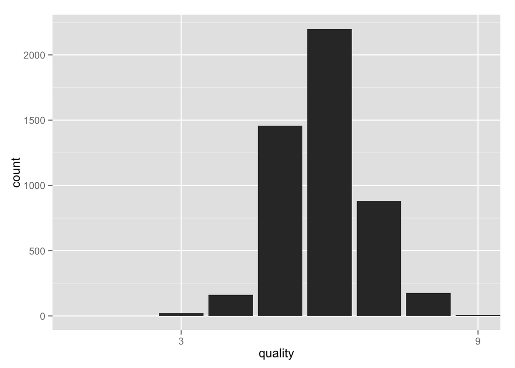

```
##    Min. 1st Qu.  Median    Mean 3rd Qu.    Max.
##   3.000   5.000   6.000   5.878   6.000   9.000
```

Similarly, we plot the histogram for the `alcohol` variable. The distribution is plotted at different `binwidth`, so that we can look at data with different “resolution”. At the coarse level (`binwidth=1`), we see that it follows a skewed distribution with most number of samples in [9, 10], followed by [10, 11], and then [11, 12], etc. At the fine level (`binwidth=0.1`), we see more irragularities of the distribution with multiple spikes, say at [9.0, 9.1], [9.5, 9.6], [10.0, 10.1], etc.

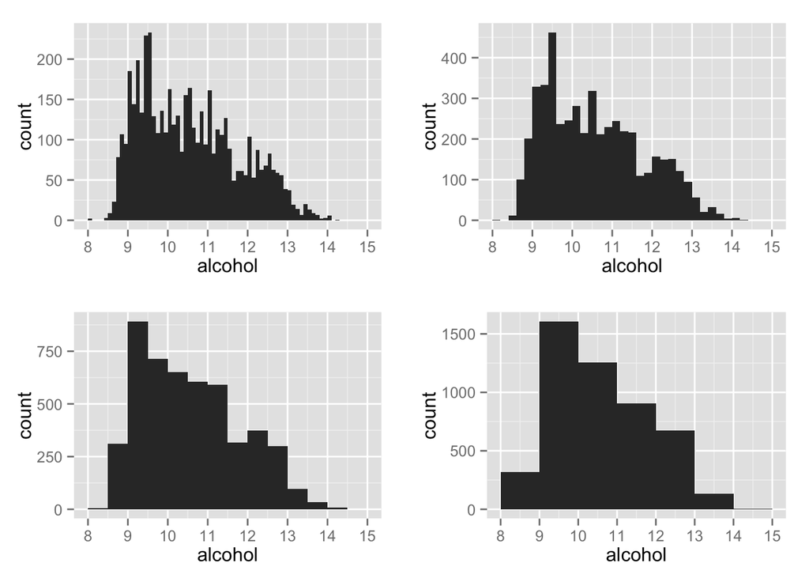

```
##    Min. 1st Qu.  Median    Mean 3rd Qu.    Max.
##    8.00    9.50   10.40   10.51   11.40   14.20
```

### What other features in the dataset do you think will help support your investigation into your feature(s) of interest?

Features such as `residual.sugar`, `sulphates`, `pH`, `chlorides` will likely contribute to the wine quality and will support our investigation.

### Did you create any new variables from existing variables in the dataset?

I created an ordered factor version of `quality` from its orignal integer version. Furthermore, I grouped the wine quality into 3 buckets [(3,4,5), (6), (7,8,9)] so that we get more samples in each bucket for better analysis.

```r
df$quality.ordered <- as.ordered(df$quality)
df$quality.bucketed <- cut(df$quality, c(2, 5, 6, 10))
```

### Of the features you investigated, were there any unusual distributions? Did you perform any operations on the data to tidy, adjust, or change the form of the data? If so, why did you do this?

During the investigation, I found the distribution of `chlorides` variable has an unusual distribution. From the histogram shown below, we see that the majority of samples lie in the range of [0, 0.1] in a normal distribution shape, but there are a small number of outliers that lie far beyond this normal range (up to 0.34), which indicates this is a long-tail distribution.

In order to better visualize this distribution, we tried two approaches 1. Cut off the samples that are beyond 0.1, and only “zoom in” to look at those in the “regular range”; 2. Plot the distribution in a `log10` scale.

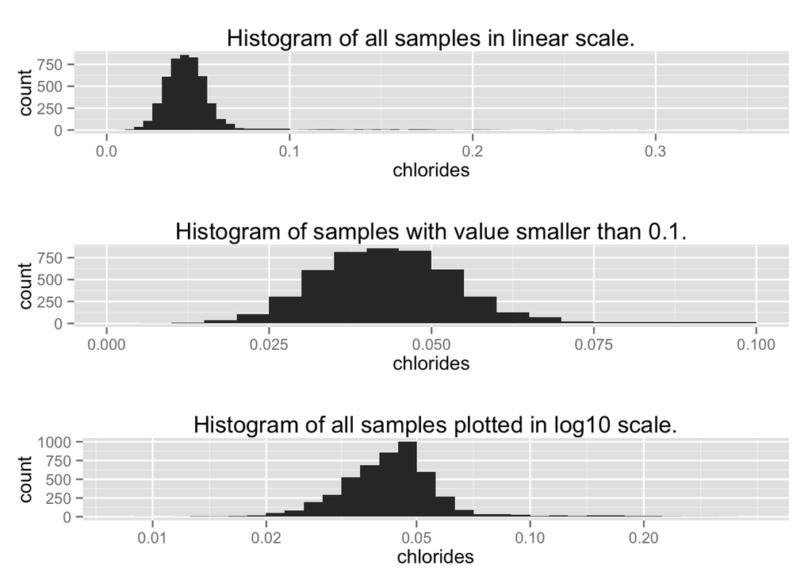

```
##    Min. 1st Qu.  Median    Mean 3rd Qu.    Max.
## 0.00900 0.03600 0.04300 0.04577 0.05000 0.34600
```

#### Fixed acidity

The normal range of `fixed.acidity` is 5.0 to 10.0. There are a small number of outliers that have values larger than this range.

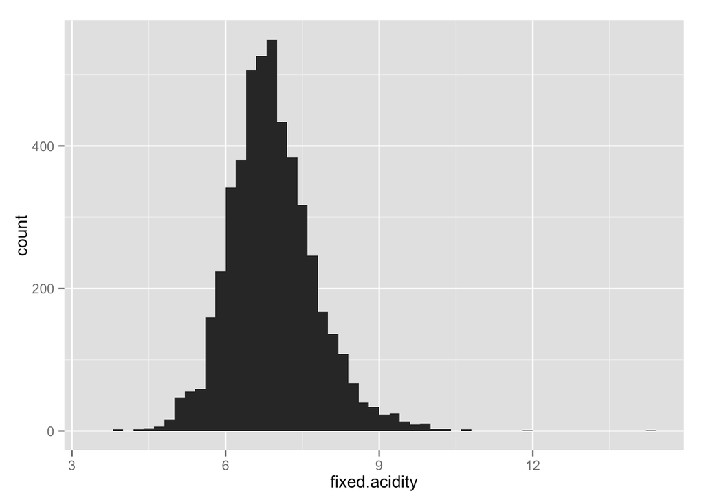

```
##    Min. 1st Qu.  Median    Mean 3rd Qu.    Max.
##   3.800   6.300   6.800   6.855   7.300  14.200
```

#### Residual sugar

The normal range of `residual.sugar` is 0.0 to 20.0. Again, there are a few outliers with values much larger than this range (up to 65.8).

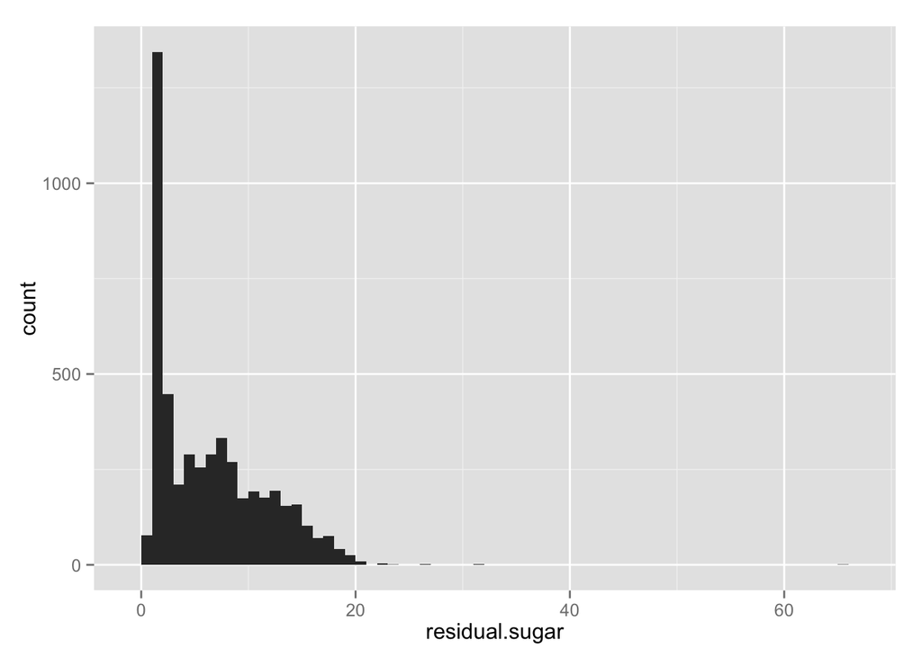

```
##    Min. 1st Qu.  Median    Mean 3rd Qu.    Max.
##   0.600   1.700   5.200   6.391   9.900  65.800
```

#### Density

The normal range of `density` is 0.99 to 1.00. Most of the samples are within this range, with a few out of the range but not significantly larger (up to 1.039).

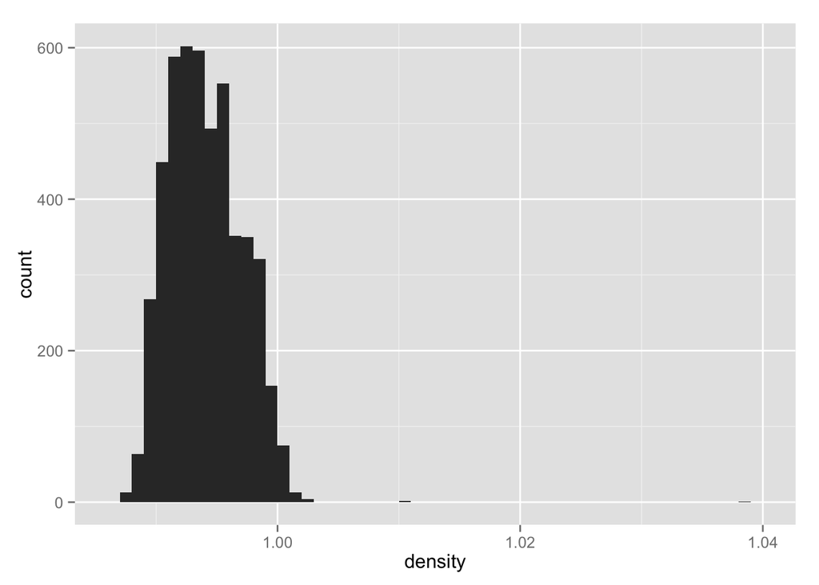

```
##    Min. 1st Qu.  Median    Mean 3rd Qu.    Max.
##  0.9871  0.9917  0.9937  0.9940  0.9961  1.0390
```

#### Sulphates

The normal range of `sulphates` is 0.2 to 1.0. Almost all samples are within this “normal range”, with a few exceptions just outside of this range but not far away.

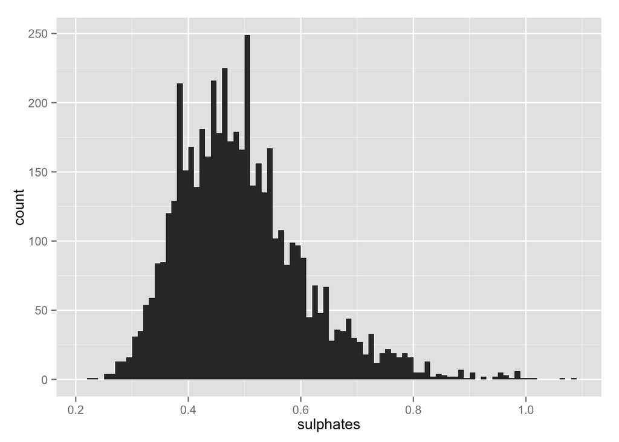

```
##    Min. 1st Qu.  Median    Mean 3rd Qu.    Max.
##  0.2200  0.4100  0.4700  0.4898  0.5500  1.0800
```

# Bivariate Plots and Analysis

### Talk about some of the relationships you observed in this part of the investigation. How did the feature(s) of interest vary with other features in the dataset?

We make a box plot for `alcohol` level for each different quality below.

Also, we see that the highest quality wine (9) has quite concentrated `alcohol` level, in other words, the variance of `alcohol` level for wine of this quality is low. Later I realized that this is because there are very few samples (5 in total) with quality score being 9, and therefore the small variance could partly be attributed to lack of data.

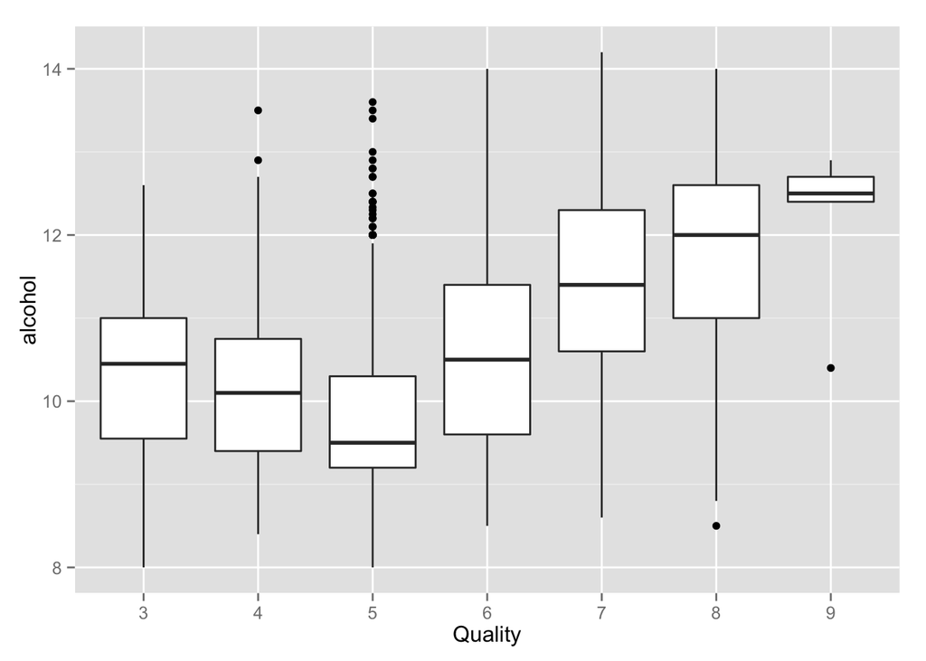

```
## Correlation:  0.4355747
```

### Did you observe any interesting relationships between the other features (not the main feature(s) of interest)?

We found that there is a weak inverse correlation between `chlorides` and wine `quality`. From the figure below, we see that apart from the lowest and highest qualities where we have relatively small number of data points, the rest of the wines tend to have a higher quality when its `chlorides` level is lower.

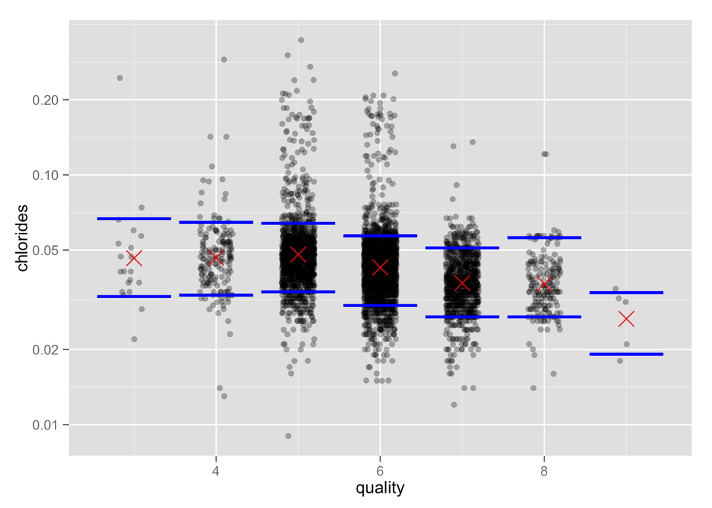

```
## Correlation:  -0.2099344
```

### What was the strongest relationship you found?

We compute correlation of quality against each individual feature in the data set, and print the result table below. We see that `alcohol` has strongest correlation (0.435) with quality, and `density` has strongest negative correlation (-0.307). The latter is not expected before analyzing the dataset.

```
##        fixed.acidity     volatile.acidity          citric.acid
##         -0.113662831         -0.194722969         -0.009209091
##       residual.sugar            chlorides  free.sulfur.dioxide
##         -0.097576829         -0.209934411          0.008158067
## total.sulfur.dioxide              density                   pH
##         -0.174737218         -0.307123313          0.099427246
##            sulphates              alcohol
##          0.053677877          0.435574715
```

#### Quality v.s. density

There is a negative correlation between density and quality. This is partly exhibited in the box plot visualization, e.g. the highest quality samples have lowest density quantiles. We also see the two density outliers (values larger than 1.005) are with medium quality value 6.

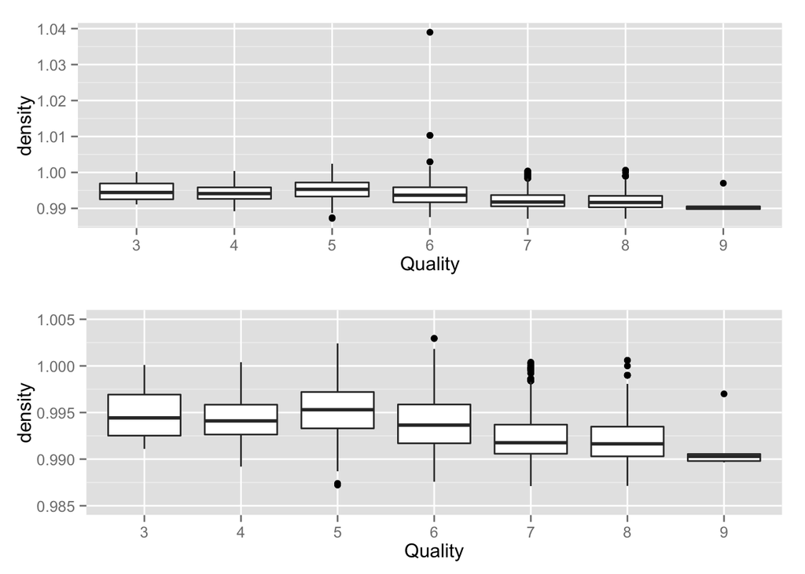

```
## Correlation:  -0.3071233
```

#### Quality v.s. sulphates

There is a very small positive correlation between sulphates and quality, which is also supported by the box plot. We can see there is not significant change of `sulphates` quantiles or median amoung different wine qualities.

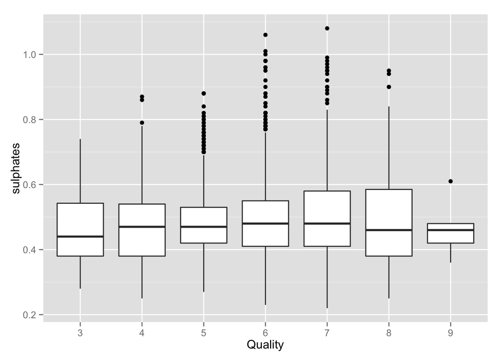

```
## Correlation:  0.05367788
```

#### Quality v.s. fixed acidity

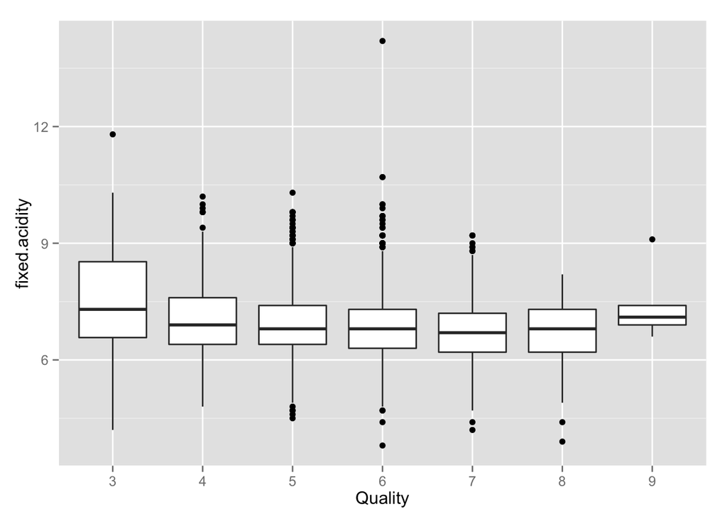

```
## Correlation:  -0.1136628
```

#### Density v.s. alcohol

We can see that there is a strong negative correlation between density and alcohol, mostly because alcohol itself has smaller density than water (which makes majority of the wine). The scatter plot confirms this observation, and also shows two outliers with large density but not extraordinary alcohol level.

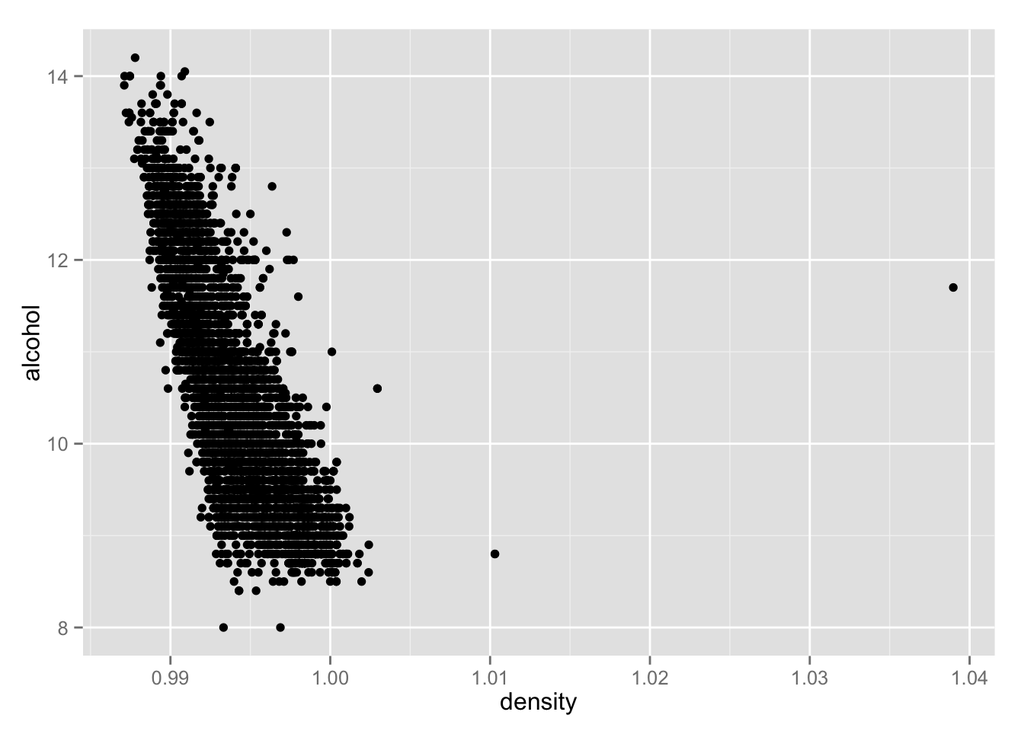

```
## Correlation:  -0.7801376
```

# Multivariate Plots and Analysis

### Talk about some of the relationships you observed in this part of the investigation. Were there features that strengthened each other in terms of looking at your feature(s) of interest?

We plot the `chlorides` with respect to `sulphates` in the figure below, and grouped and colored by different wine quality. From this plot we see that conditioned on wine quality group, the `chlorides` is mostly independent (constant) with respect to `sulphates`. Also we see that low quality wine tends to have higher `chlorides` level while high quality wine tends to have lower `chlorides` level, despite the `sulphates` roughly span the same range for each quality group.

We also added the scatter plot of all data points, and we can see the variation of `chlorides` given `sulphates` is quite large, but the general trend is visible: low quality wines (red points) tend to have larger `chlorides` than high quality wines (blue points).

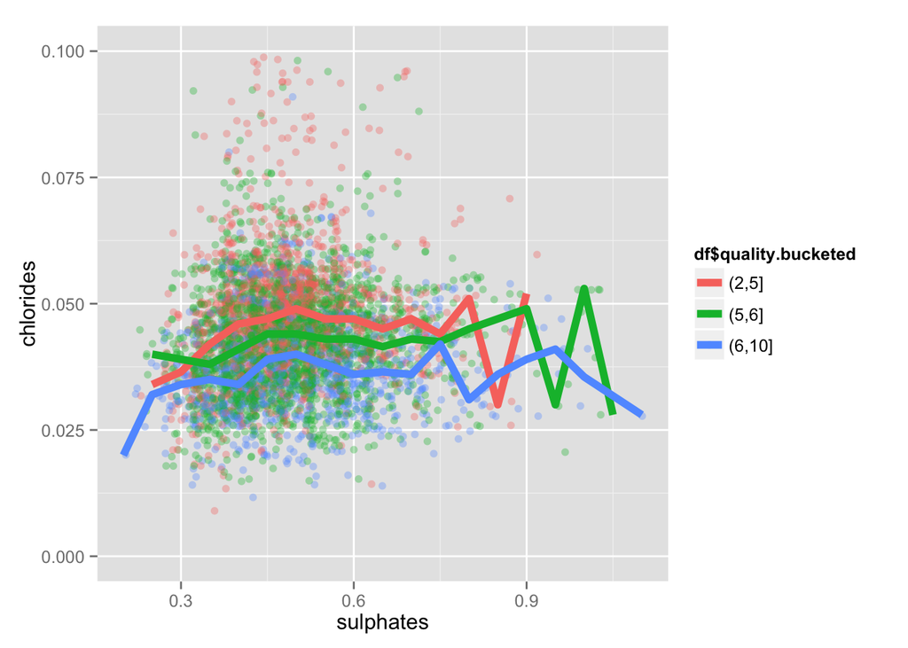

### Were there any interesting or surprising interactions between features?

One of the interesting and somewhat surprising fact I found is that the relations of most pairs of features are independent on wine quality. Take the following point for example, when plotting `density` against `alcohol`, grouped by different quality, we see that they mostly follow the same decreasing relationship, and the curves are actually very close or indistinguishable from each other. After thinking about it more, I believe it is reasonable that the relationships of one physical/chemical property against another physical/chemical property are mostly consistent and independent to quality, because this is usually governed by the laws of physics/chemistry instead of human taste. For example, the more alcohol some wine contains, the lighter (smaller density) that it will be, because alcohol has smaller density than water (which makes most part of the wine), and this fact holds regardless how the wine tastes.

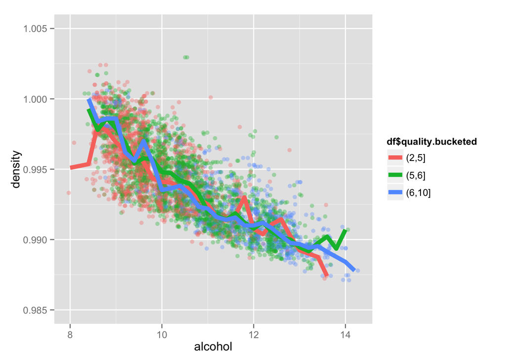

### OPTIONAL: Did you create any models with your dataset? Discuss the strengths and limitations of your model.

# Final Plots and Summary

### Plot One

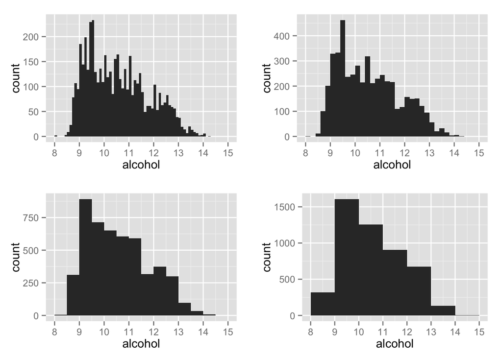

### Description One

In this plot we show the histogram of samples according to their `alcohol` level.

The histograms are plotted at different binwidth, showing different “resolution” of the data. At the coarse resolution, we see general trends, e.g. there are more wines with `alcohol` level in [9,10] than in [11,12]; while at the fine resolution, we see individual spikes, say there are a lot of wines with `alcohol` level in [9.5, 9.7].

In general, we find that the distribution of `alcohol` level in the data set is skewed towards lower end, that is there are more wines with lower `alcohol` level (9 to 10) than those with higher `alcohol` level (11 to 12).

### Plot Two

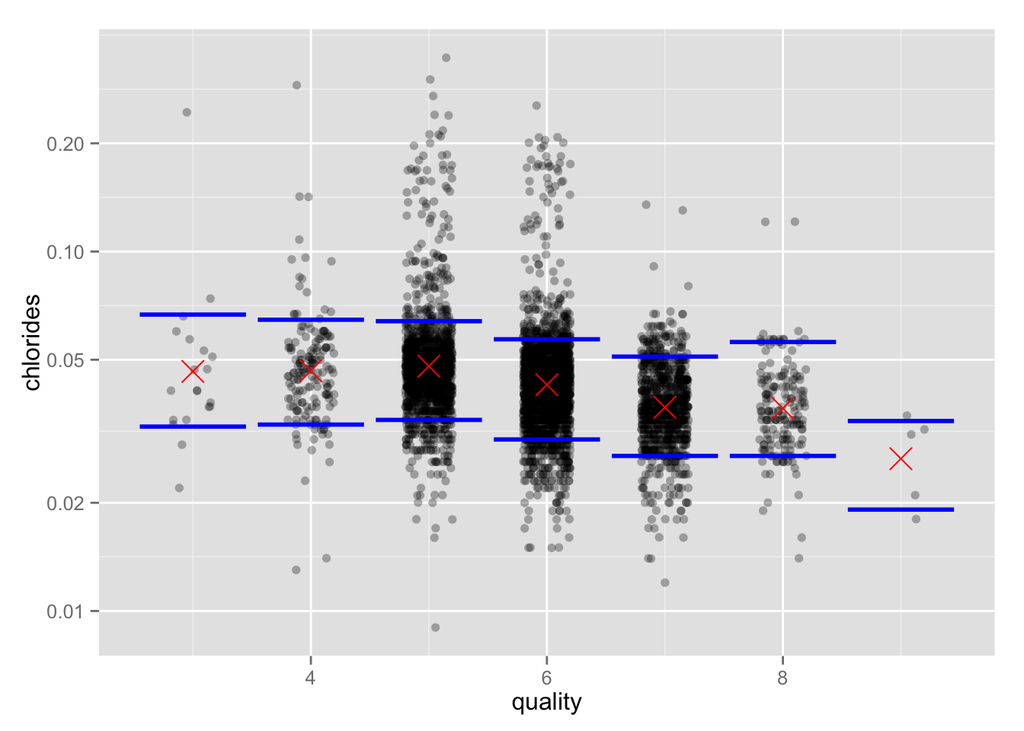

```
## Correlation:  -0.2099344
```

### Description Two

In this plot we draw the quality of wine v.s. the their `chlorides` level.

In addition, we plotted the 10% and 90% quantile (blue bars) as well as the mean (red cross) to visualize the general trend of data.

### Plot Three

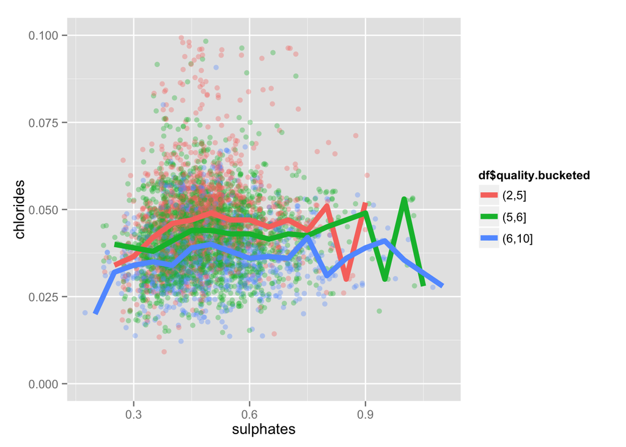

### Description Three

In this plot we draw the relationship between two chemical properties of the wine: `chlorides` v.s. `sulphates`, conditioned on wine quality group.

We see that given a quality group, the `chlorides` is mostly independent of `sulphates`, and low-quality wines tend to have higher `chlorides` than high-quality ones, although their `sulphates` have similar span.

In addition, we also add a layer of scatter plot for in order to show the scope of variation, in which we see although the variation is quite large, the general trend that low quality wines (red points) tend to have larger `chlorides` than high quality wines (blue points) is clearly visible.

# Reflection

I have several take-home message from this project:

- Understanding the range of data is very important. It is usually very helpful to first plot the histogram of the variables in order to get a sense of how well they are distributed, and decide a reasonable axis scale to present them. Without such a step, the result visualization can be very skewed and hard to interpret.
- Having a reasonable size for the dataset is important. When there are too few number of data point, the statistical analysis might be less reliable. For example, there are only 5 samples of quality 9 wine, and a box plot or quantile computed from this 5 samples might not be as robust as the one that is from, say 500 samples.
- Some unexpected results is not necessarily wrong; they might just be the fact that we overlooked before. For example, I expect conditioned on wine quality, the curves of one physical/chemical property against another should be distinguishable from another. This however is not true, as discovered from analysis, those relationships are often governed by physical/chemical laws and therefore not very dependent on human tastes.